# ~ Exploration of US Flight Data ~

## A glimpse into flight data for Pittsburgh, PA in 1988 and 2007: With a focus on delays and the month of November

*Created by Miles Murphy*

*October 31, 2020*

## Data Exploration

As discussed earlier, there are at least seven aspects of this data which will be examined in greater detail. They are:

- The most popular month for travel in 88 and 07
- The most popular day of the week for travel in 88 and 07
- The most popular origins for flights arriving in Pittsburgh
- The most popular destinations for flights departing from Pittsburgh
- The length of flights
- The length of delays for flights that experience them
- The most common type of delay

They will undergo Univariate Exploration and some many be combined in bivariate or multivariate exploration if their results encourage a deeper exploration.

### Univariate Exploration

#### 1. Most Popular Month to Fly

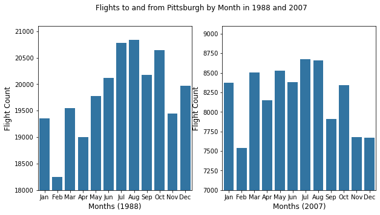

#### 2. Most Popular Day of the Week to Fly

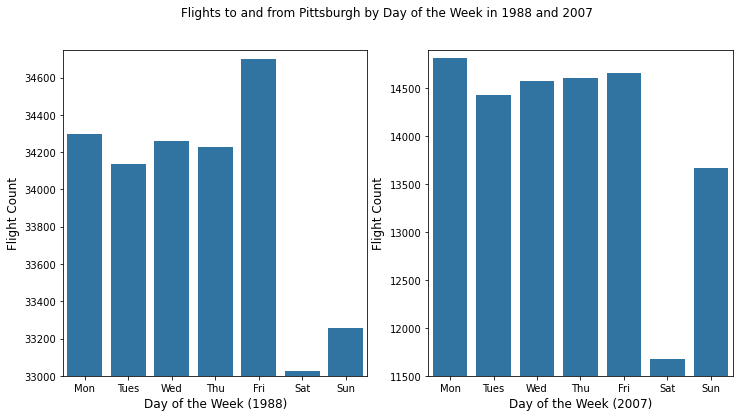

#### 3. Most Popular Flight Origin

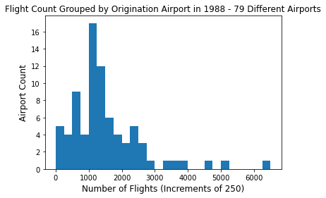

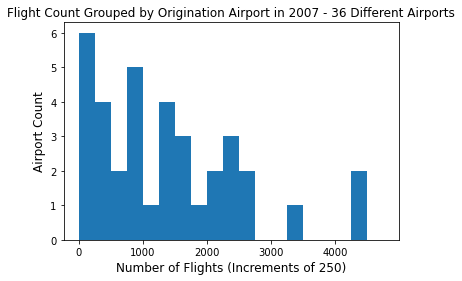

#### 4. Most Popular Flight Destination

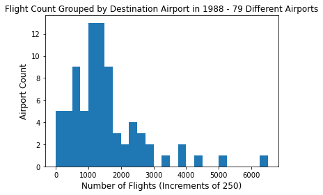

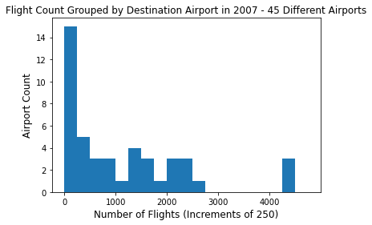

#### 5. Flight Length

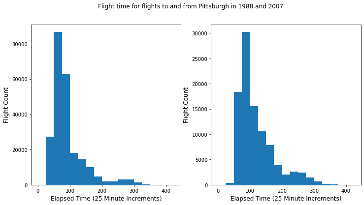

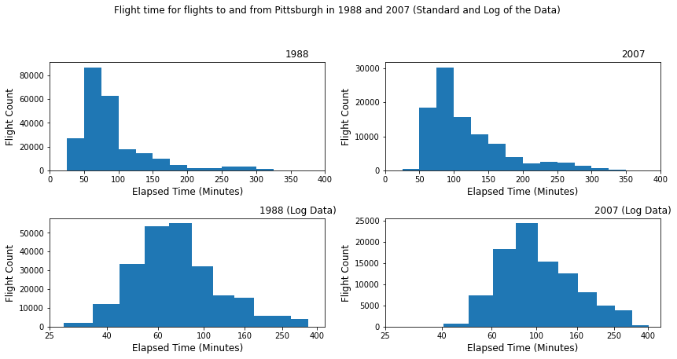

#### 6. Delay Length

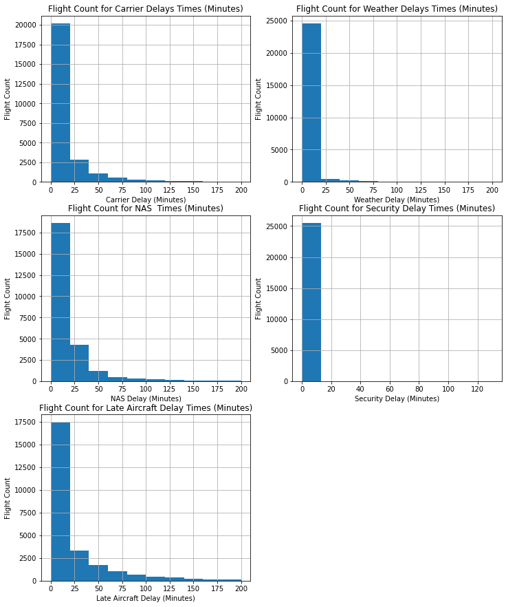

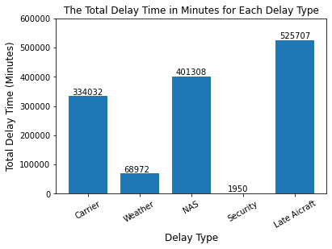

### Bivariate Exploration

#### 1. Total delay time and delay type

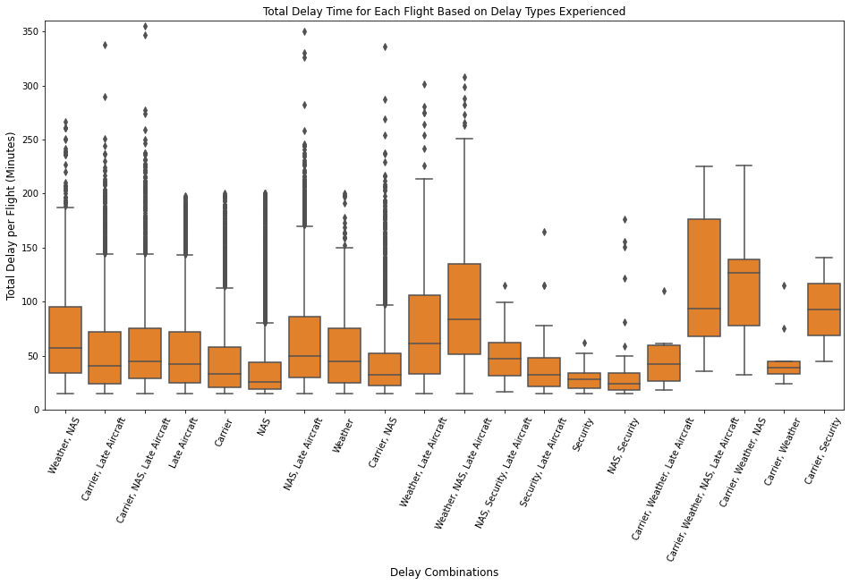

#### 2. Busiest day of the week to travel by month

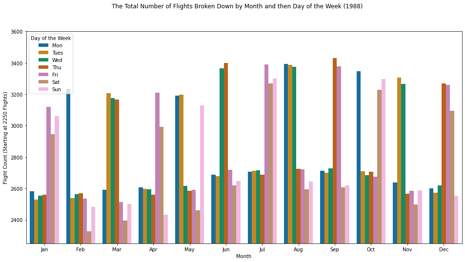

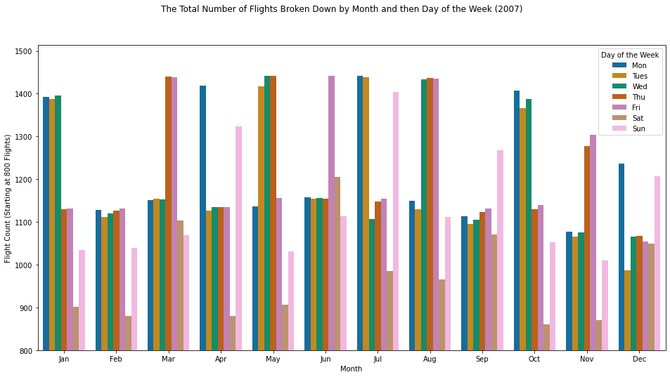

#### 3. Flight Delays by Day of the Week in Pittsburgh in November of 2007

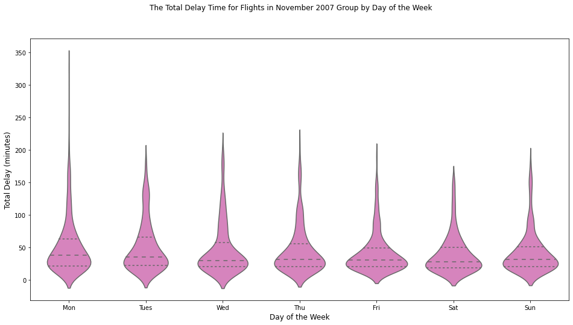

### Multivariate Exploration

#### 1. Average Total Delay Time for the Top 5 Delay Types divided by Day of the Week

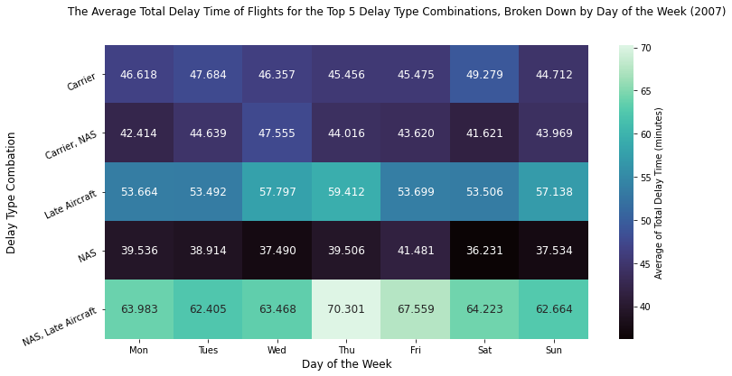

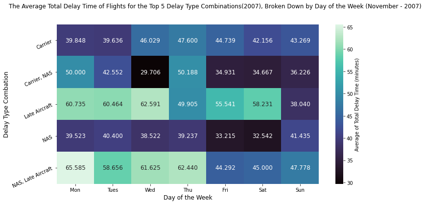

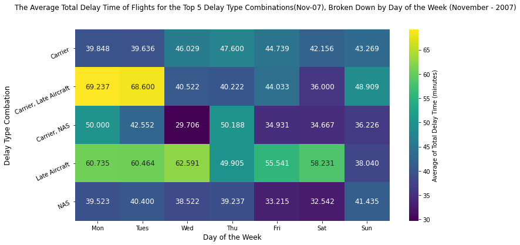

#### 2. Destinations on November 20th 2007, Delay Types, and the Total Elapsed Time

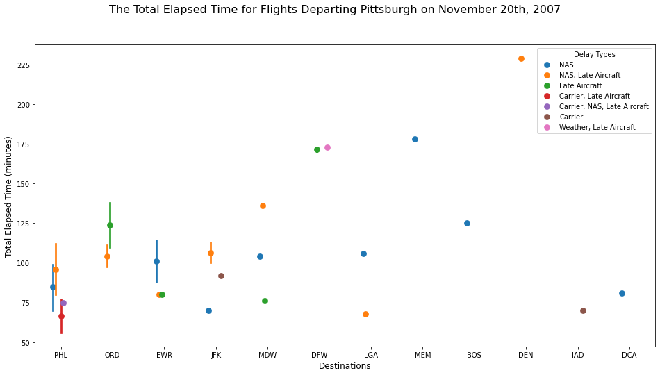